### Condidering the repsonse variable as a categorical feature

```r
df_cat <- df_derived_t %>%
  mutate(outcome = ifelse(output < 0.33, "event", "non-event"),
         outcome = factor(outcome, levels = c("event", "non-event"))) %>%
  select(-y) %>%
  select(-output)

df_cat %>% glimpse()
```

```
## Rows: 1,252
## Columns: 15
## $ x1      <dbl> 0.025878, 0.030768, 0.019325, 0.306212, 0.031296, 0.031073, 0.…
## $ x3      <dbl> 0.492830, 0.498460, 0.258360, 0.255385, 0.264387, 0.260915, 0.…
## $ x4      <dbl> 0.012770, 0.055779, 0.012424, 0.056190, 0.056594, 0.055192, 0.…
## $ v1      <dbl> 0.275651, 0.343204, 4.998508, 5.090153, 5.031107, 9.977407, 0.…
## $ v2      <dbl> 0.033657, 0.027082, 0.030259, 0.052342, 0.517705, 0.532436, 1.…
## $ v3      <dbl> 1.166214, 1.260579, 1.298285, 1.322005, 1.368195, 1.298797, 1.…
## $ v4      <dbl> 0.408402, 0.664248, 0.412870, 0.652111, 0.533701, 0.857509, 0.…
## $ v5      <dbl> 0.525226, 2.866343, 0.409007, 0.861594, 6.451933, 0.958574, 0.…
## $ m       <chr> "A", "A", "A", "A", "A", "A", "A", "A", "A", "A", "A", "A", "A…
## $ x5      <dbl> 0.212588, 0.153418, 0.689014, 0.348834, 0.388381, 0.625701, 0.…
## $ w       <dbl> 0.50619858, 0.47195344, 0.07709835, 0.10712990, 0.80796683, 0.…
## $ z       <dbl> 1.25050808, 1.39745312, 0.05731369, 0.83844661, 0.65315580, 0.…
## $ t       <dbl> 0.009277586, 0.009294651, 0.151249854, 0.266428788, 2.60462924…
## $ bc_x2   <dbl> -1.272165, -1.253178, -3.195615, -2.871930, -1.260650, -3.0171…
## $ outcome <fct> non-event, non-event, non-event, event, non-event, non-event, …
```

**Checking the fraction of the outcome.**

```r
df_cat %>%
  count(outcome)
```

```
## # A tibble: 2 × 2
##   outcome       n
##   <fct>     <int>
## 1 event       436
## 2 non-event   816
```

We will get the fraction of data when the event occurs.

```r
sum(df_cat$outcome == 'event') / (sum(df_cat$outcome == 'event') + sum(df_cat$outcome == 'non-event'))
```

```
## [1] 0.3482428
```

Therefore almost `35%` of the outcome feature is categorized as an `event` which is not as good as 50-50 split but is not that bad.

**Visualizing the outcome based on bar chart**

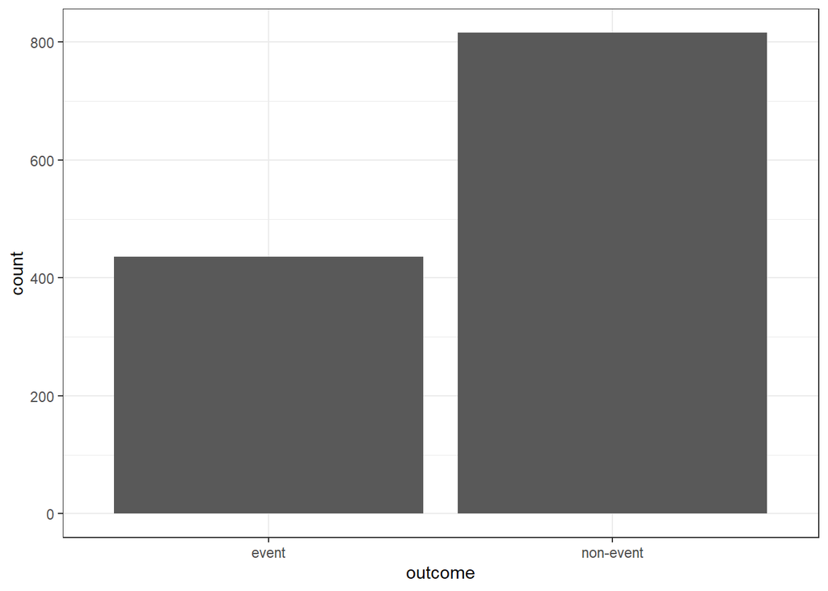

```r
df_cat %>%
  ggplot(mapping = aes(x = outcome)) +
  geom_bar() +
  theme_bw()
```

**Visualizing the categorical input `m` based on the outcome**

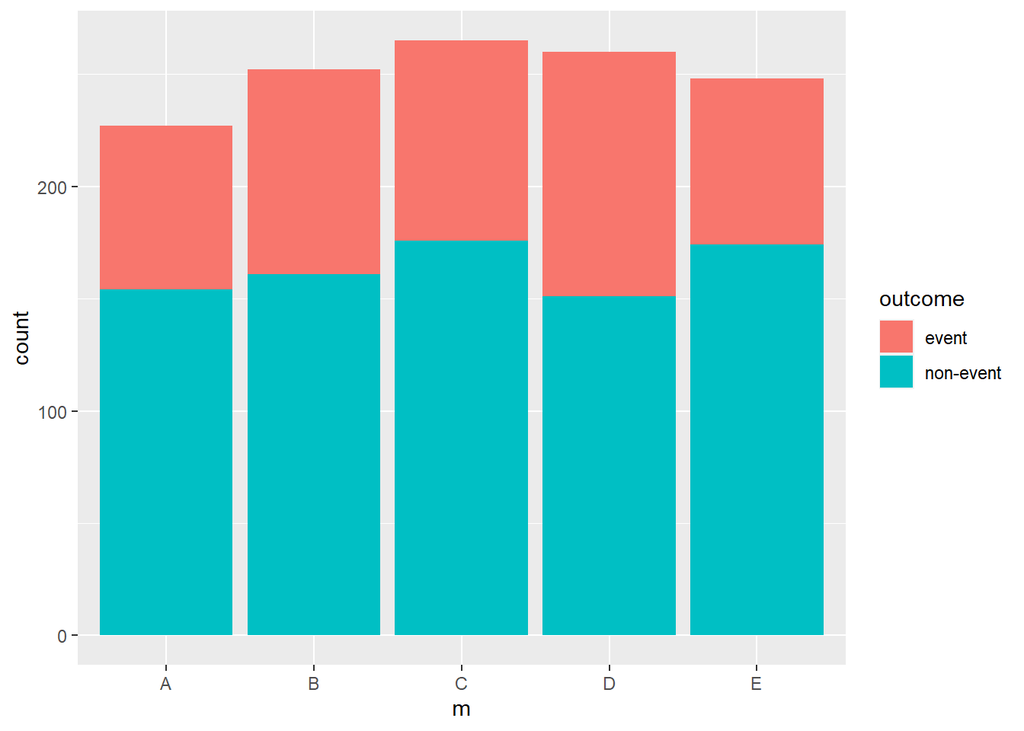

```r
df_cat %>%
  ggplot(mapping = aes(x = m)) +
  geom_bar(mapping = aes(fill = outcome))
```

We can see the the outcome variable is distributed evenly along each machine.  
There is no one machine which contains only `event` or `non-event`.

To get a better understanding of the graph we will show the proportions of events and non-event on each machine using a stacked bar chart.

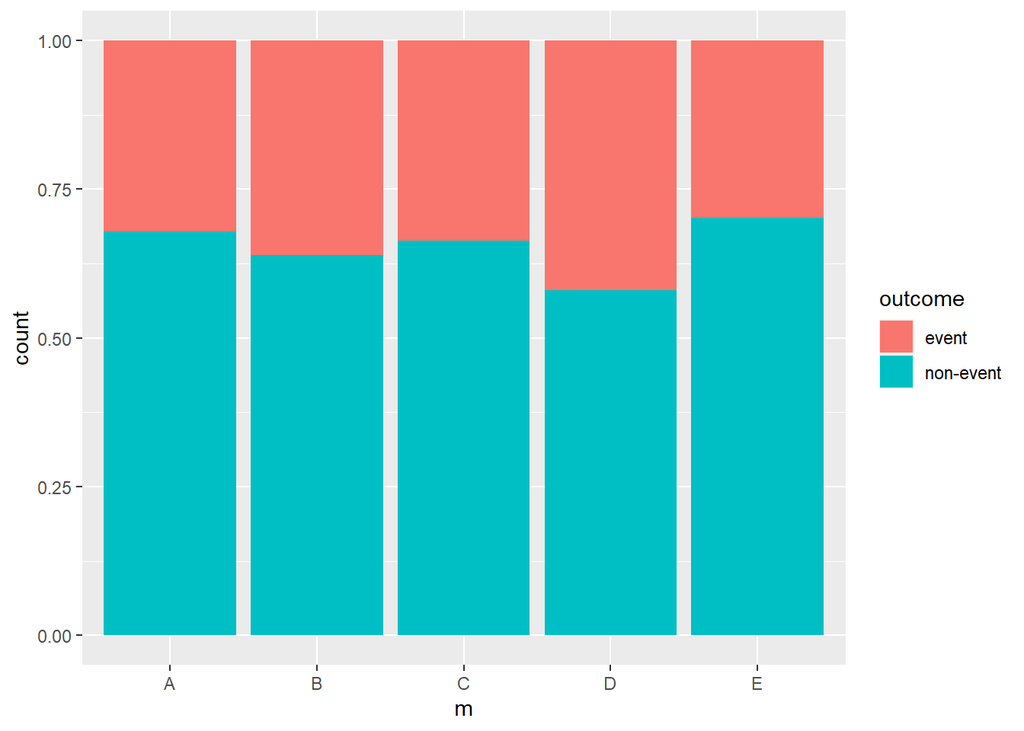

```r
df_cat %>%
  ggplot(mapping = aes(x = m)) +
  geom_bar(mapping = aes(fill = outcome), position = 'fill')
```

We can see that machine D has slightly higher proportion of event but its almost similar for all the machines.

**Now we will try to visualize the distribution of the continuous variables based on the outcome variable**

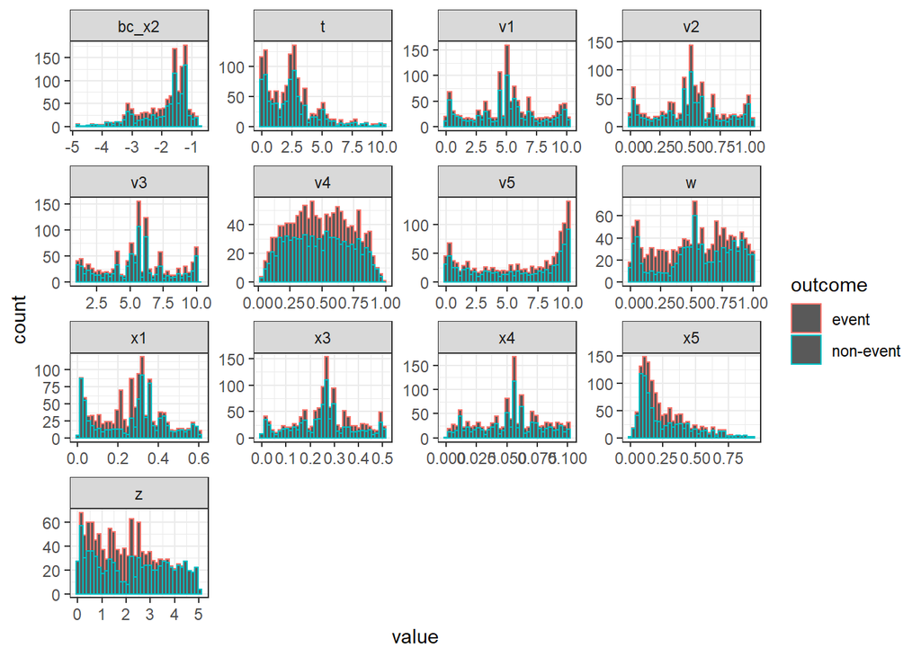

```r
df_cat %>%
  select(-m) %>%
  tibble::rowid_to_column() %>%
  pivot_longer(!c("rowid", "outcome")) %>%
  ggplot(mapping = aes(x = value)) +
  geom_histogram(mapping = aes(color = outcome), bins = 35) +
  facet_wrap(~name, scales = 'free') +
  theme_bw()
```

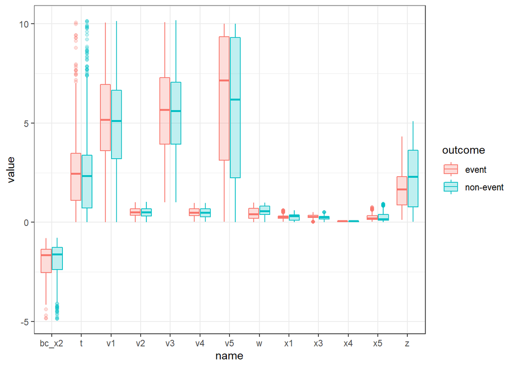

```r
df_cat %>%
  select(-m) %>%
  tibble::rowid_to_column() %>%
  pivot_longer(!c("rowid", "outcome")) %>%
  ggplot(mapping = aes(x = name, y = value)) +
  geom_boxplot(mapping = aes(group = interaction(name, outcome),
                             fill = outcome, color = outcome), alpha = 0.25) +
  theme_bw()
```

```r
df_cat_scaled <- df_cat %>%
  select(-m) %>%
  select(-outcome) %>%
  scale(center = TRUE, scale = TRUE) %>%
  as.data.frame() %>%
  mutate(m = df_cat$m,
         outcome = df_cat$outcome)
```

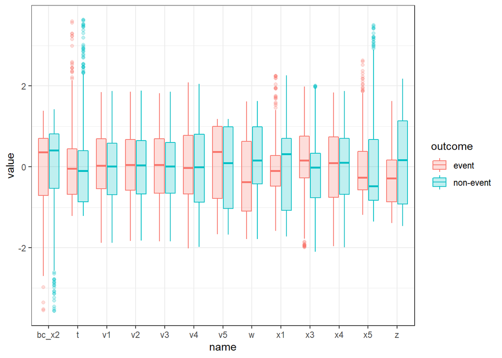

```r
df_cat_scaled %>%
  select(-m) %>%
  tibble::rowid_to_column() %>%
  pivot_longer(!c("rowid", "outcome")) %>%
  ggplot(mapping = aes(x = name, y = value)) +
  geom_boxplot(mapping = aes(group = interaction(name, outcome),
                             fill = outcome, color = outcome), alpha = 0.25) +
  theme_bw()
```

All the variables are now scaled.

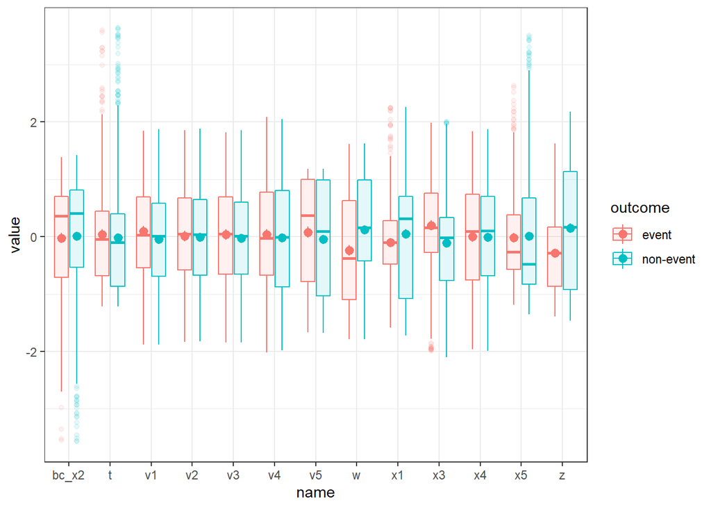

```r
df_cat_scaled %>%
  select(-m) %>%
  tibble::rowid_to_column() %>%
  pivot_longer(!c("rowid", "outcome")) %>%
  ggplot(mapping = aes(x = name, y = value)) +
  geom_boxplot(mapping = aes(group = interaction(name, outcome), fill = outcome, color = outcome), alpha = 0.1) +
    stat_summary(fun.data = 'mean_se',
               fun.args = list(mult = 2),
               mapping = aes(group = interaction(name, outcome),
                             color = outcome),
               position = position_dodge(0.75)) +
  theme_bw()
```

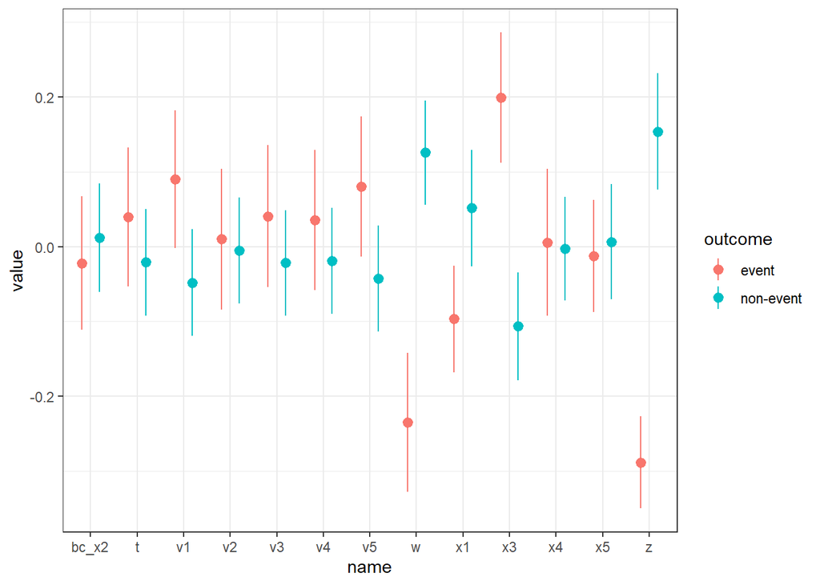

```r
df_cat_scaled %>%
  select(-m) %>%
  tibble::rowid_to_column() %>%
  pivot_longer(!c("rowid", "outcome")) %>%
  ggplot(mapping = aes(x = name, y = value)) +
   stat_summary(fun.data = 'mean_se',
               fun.args = list(mult = 2),
               mapping = aes(group = interaction(name, outcome),
                             color = outcome),
               position = position_dodge(0.75)) +
  theme_bw()
```

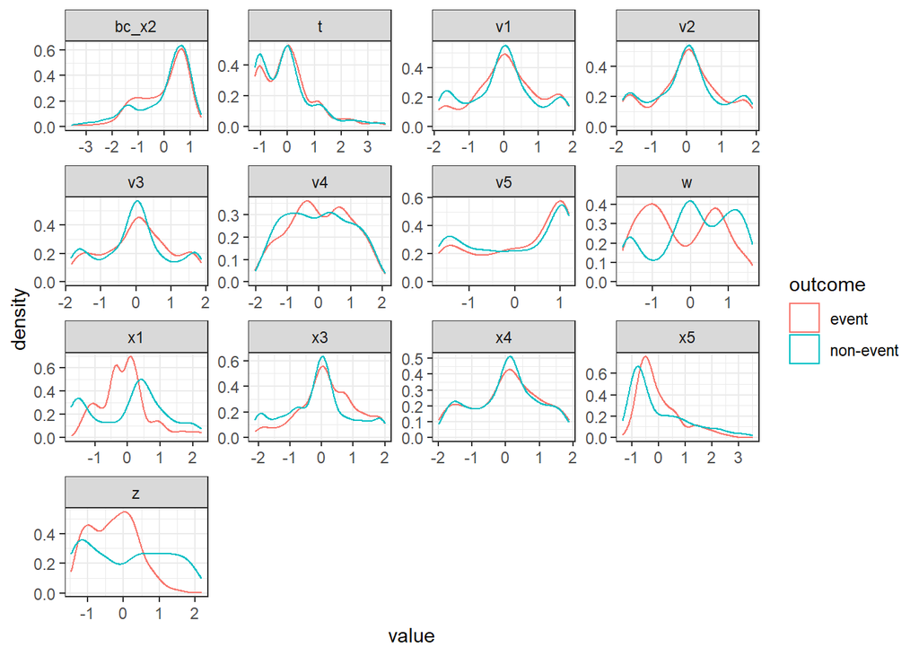

```r
df_cat_scaled %>%
  select(-m) %>%
  tibble::rowid_to_column() %>%
  pivot_longer(!c("rowid", "outcome")) %>%
  ggplot(mapping = aes(x = value)) +
  geom_density(mapping = aes(group = outcome, color = outcome)) +
  facet_wrap(~name, scales = "free") +
  theme_bw()
```

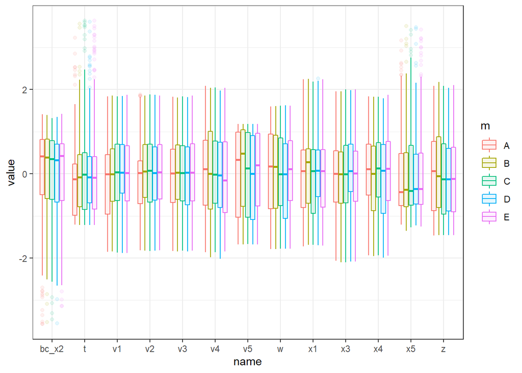

```r
df_cat_scaled %>%
  select(-outcome) %>%
  tibble::rowid_to_column() %>%
  pivot_longer(!c("rowid", "m")) %>%
  ggplot(mapping = aes(x = name, y = value)) +
  geom_boxplot(mapping = aes(group = interaction(name, m), fill = m, color = m), alpha = 0.1) +
  theme_bw()
```